# Laboratorio 3 - Bonus Track POM

### Carolina Crisci, Gonzalo Perera, Angel Segura

# Introducción

En este bonus track veremos algunas básicas del método de Picos sobre la variedad (POM en inglés por *Peaks over Manifolds*) vistos en el teórico. Ver Segura y Perera 2023 (https://www.scirp.org/journal/paperinformation.aspx?paperid=114919). Recordemos en términos generales que la afectación, que es el área afectada multiplicada por la relevancia del área sigue una distribución de Pareto Generalizada (DPG).

Recordemos que en este caso se trata de avances o retrocesos que siguen una topografía determinada. A esto se le conoce como una variedad. Deja de ser un problema unidimensional.

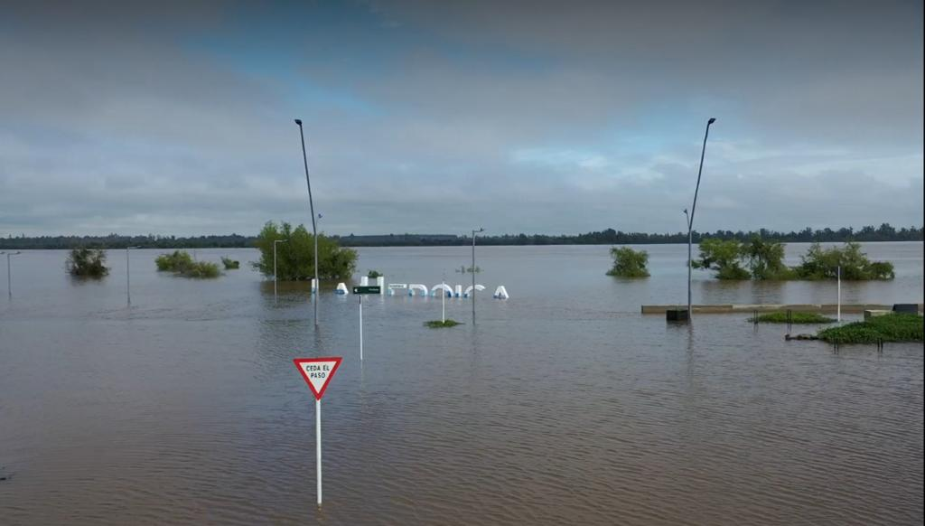

Si pensamos que la costa es la línea $C$, ahora vamos a tener un umbral que sigue la topografia ($C_u$) y el área rayada es la superficie en donde la marea o la variable que sea excedió ese umbral.

## Area del exceso

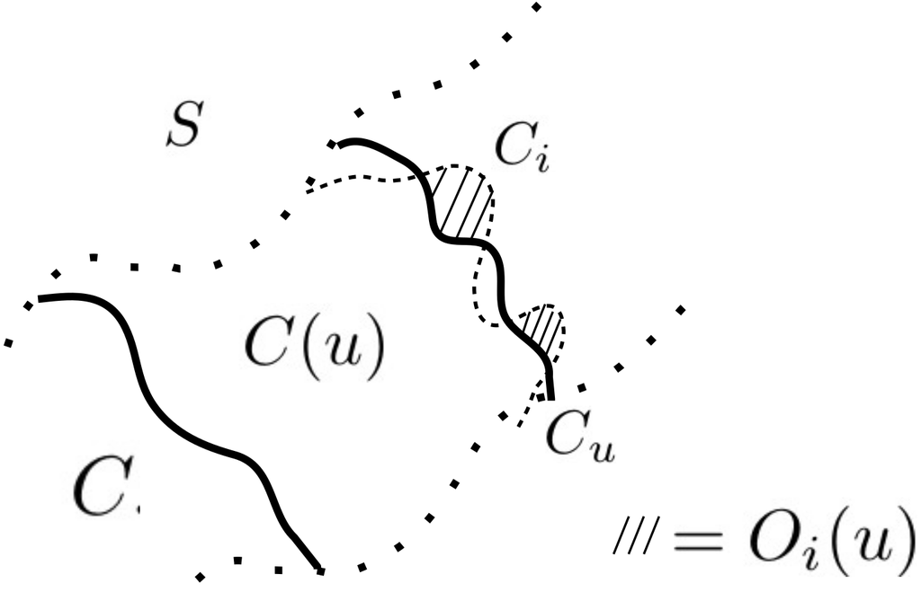

Ejemplo de area en exceso

En el ejemplo que utilizaremos, simularemos una linea de costa, y un régimen mareal. Definiremos un umbral a partir del cual entendemos hay afectación. En este caso, para simplificar, definiremos que la afectación es equivalente para cualquier parte de la playa. Este supuesto simplifica un poco las cuentas, pero podriamos suponer que en cierta zona, la llegada de la inundación tiene consecuencias trágicas y en esas zonas, multiplicar el área afectada por un coeficiente mayor a 1.

## Simulación de la data para un ejemplo de POM en mareas

Vamos a simular un régimen de mareas con una función gentilmente tomada de la internet. Recordemos que al definir la función, no pasa nada. Solo se crea un objeto que es una función y luego nos permitirá operar. La función se llama “waves” y tiene como argumentos de entrada el tiempo (time_in), los parámetros “alpha”, “beta”, la frecuencia “frec” y el desfazaje “phi” que por defecto asigna como $0$.

```r
#https://beckmw.wordpress.com/2017/04/12/predicting-tides-in-r/
# function for creating sine wave
waves <- function(time_in, alpha = 0, beta = 1, freq = 24, phi = 0){

  # timestep per hour
  time_step <- 60 / unique(diff(time_in))

  # set phi as difference in hours from start of time_in
  phi <- min(time_in) + phi * 3600
  phi<- as.numeric(difftime(phi, min(time_in)))
  phi <- phi / time_step

  # get input values to cos func
  in_vals <- seq(0, length(time_in), length = length(time_in))
  in_vals <- in_vals / time_step
  in_vals <- 2 * pi * in_vals * 1 / freq

  # wave
  y <- alpha + beta * sin(in_vals + phi)

  return(y)

}
```

Generaremos luego una serie temporal entre Febrero de 2021 y mayo de 2021 con un paso de 30 minutos (media hora), en plena pandemia y muy aburridos de estar en casa.

```r
x <- as.POSIXct(c('2021-02-01', '2021-05-01'))
x <- seq(x[1], x[2], by = 60 * 30)
```

Luego generamos 3 ondas sinusoidales

```r
# a: default
# b: amplitude 0.5, 48 hour period
# c: amplitude 2, 12 hour period
a <- waves(x)
b <- waves(x, beta = 0.5, f = 48)
c <- waves(x, beta = 2, f = 12)
```

Ahora graficaremos las 3 ondas que generan nuestra marea perfecta para visualizarla (aunque no se ve mucho).

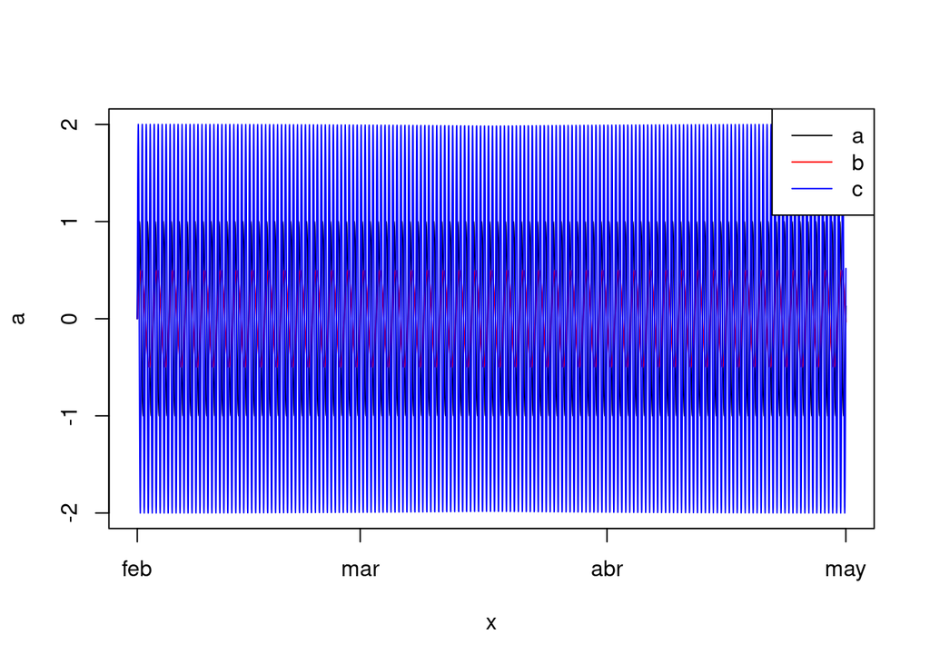

```r
plot(x, a, type="l", ylim=c(-2,2))
lines(x,b, type="l", col="red")
lines(x,c, type="l", col="blue")
legend("topright", legend=c("a","b","c"), col=c("black","red","blue"),lty=1)
```

Si agregamos los 3 componentes de la marea, tendremos la altura media del mar en el tiempo y graficamos una parte de la serie para ver los cambios en la altura del mar.

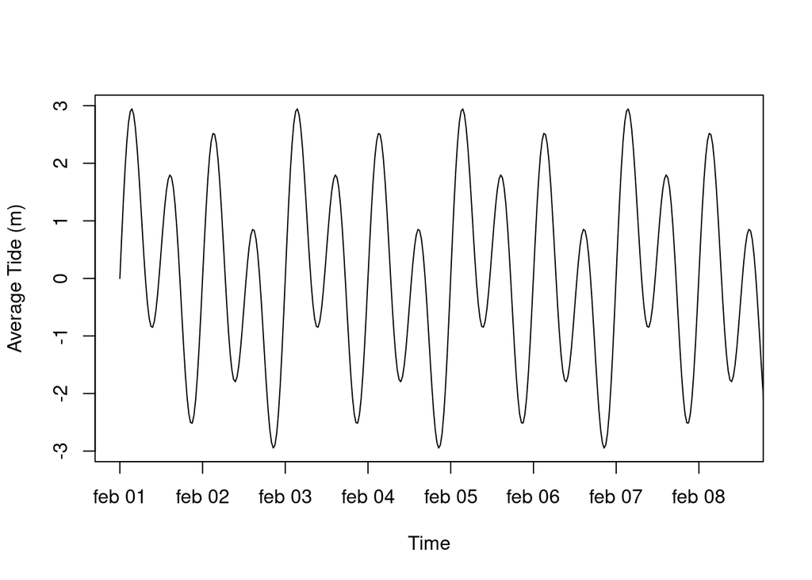

```r
# Esto define el promedio temporal de una región de la costa.
Averagetide<-rowSums(cbind(a,b,c))

plot(x,Averagetide, type="l", xlim=c(x[1], x[360]), axes=FALSE, xlab="Time", ylab="Average Tide (m)")
axis.POSIXct(1, at=seq(x[1], x[360], by="day"), format="%b %d")
box()
axis(2)
```

### Umbral por donde considero que hay peaks que sobrepasaron.

```r
u<-max(Averagetide)*1.20 # Exceden la maxima marea promedio en mas del 20%
```

## Dinámica en el espacio

Luego, generamos para cada punto a lo largo de una costa de 100 km una serie de ondas con el mismo promedio, pero con perturbaciones.

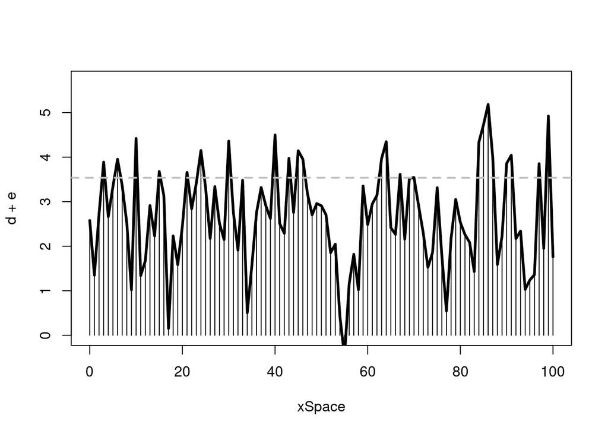

```r
#Random sinusoidal componente beta aleatorio y cambios en la posición espacial del maximo (reflejado en Phi.
#Se suman a la onda promedio.
xSpace<- seq(0,100, by=1)

Period<- 20# T- aqui es en el espacio
frec<- 1/Period
Phi<- 0 # Desfasaje espacial
w<-2*pi*frec
Beta<- 1
# un ejemplo concreto
d<- Averagetide[10] + Beta* sin(w*xSpace+ Phi)

set.seed(43)
e<- rnorm(length(xSpace), 0,1)

#x11()
plot(xSpace,d+e, lwd=1, type="h", ylim=c(0, max(d+e,na.rm=T)*1.10))
lines(xSpace,d+e, lwd=3, type="l")
abline(h=u, lty=2, col="grey", lwd=2)
```

Genero el loop para cada muestreo de como era la situación de la marea en cada punto y en cada tiempo.

```r
TideMAt<-matrix(NaN, ncol=length(x), nrow=length(xSpace))

set.seed(6999)
for(i in 1:ncol(TideMAt)){
Beta<- rnorm(1, 0.2,0.8)
PhiRnd=0#runif(1, 0,100) # Agrego un Desfasaje de donde comienza el período para que sea un poco diferente en cada caso.

d<- Averagetide[i] + Beta* sin(w*xSpace+ PhiRnd)
# Agrego un componente totalmente aleatorio
e<- rnorm(length(xSpace), 0,0.5)
TideMAt[,i]<- e+d
}
```

# Comienzo ajuste de POM simplificado

```r
selExcess<-which(apply(TideMAt, 2, function(X) any(X>u))) # recordad que u lo definimos antes
100* length(selExcess)/ncol(TideMAt) # % excesos
```

```
## [1] 15.86707
```

```r
length(selExcess)
```

```
## [1] 678
```

Si vemos el spaghetti de todos los casos donde marcamos cada hora los niveles de la marea en la playa

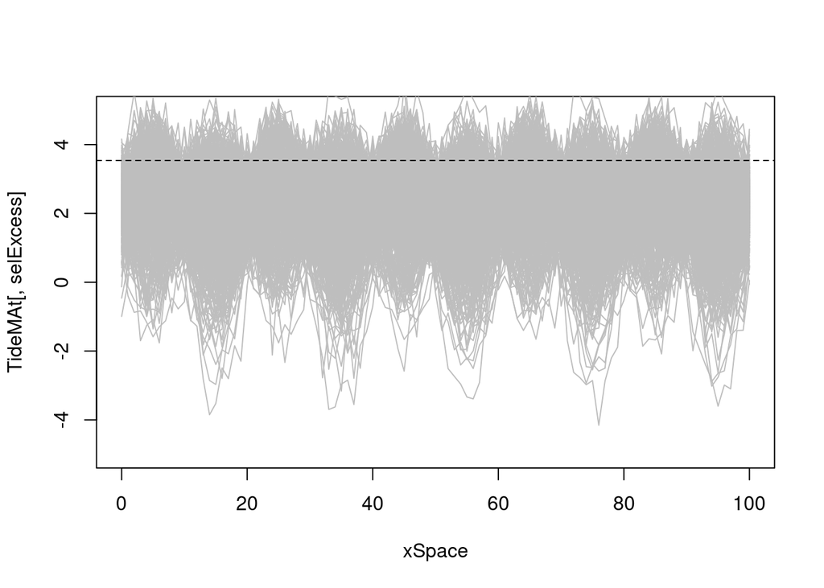

```r
matplot(xSpace,TideMAt[,selExcess], lwd=1, type="l", ylim=c(-5,5),col="grey", lty=1)
abline(h=u, lty=2)
```

## Escojo los casos en los que hubo excesos

```r
ExcessMat<-TideMAt[,selExcess]
dim(ExcessMat)
```

```
## [1] 101 678
```

Con los excesos seleccionados, pasamos a calcular el área de los excesos. Recuerden que es el área rayada en la figura del inicio.

```r
AreaMat<-(ExcessMat-u)/1000 # Para que el área quede en km2 (Deltay en metros y Deltax en km)
AreaMat[AreaMat<=0]<-NaN

AreaExceso<-colSums(AreaMat, na.rm=TRUE)
```

De acuerdo con la derivación de POM, la afectación debería seguir una distribución de pareto generalizada (DPG). Por lo que podemos ajustar al vector “AreaExceso” una distribución de pareto generalizada. Recordemos cargar el paquete {POT} para poder ajustar la distribución de pareto generalizada.

```r
require(POT)
GPsim <- fitgpd(AreaExceso, 0.005) # Umbral=1e2
ksim<-GPsim$fitted.values["shape"]
sigmasim<-GPsim$fitted.values["scale"]
```

Podemos estimar el intervalo de confianza de los estimadores.

```r
summary(GPsim)
```

```
## List of 23
##  $ fitted.values : Named num [1:2] 7.23e-03 -1.17e-13
##   ..- attr(*, "names")= chr [1:2] "scale" "shape"
##  $ std.err       : Named num [1:2] 0.000754 0.088971
##   ..- attr(*, "names")= chr [1:2] "scale" "shape"
##  $ std.err.type  : chr "observed"
##  $ var.cov       : num [1:2, 1:2] 5.68e-07 -4.64e-05 -4.64e-05 7.92e-03
##   ..- attr(*, "dimnames")=List of 2
##   .. ..$ : chr [1:2] "scale" "shape"
##   .. ..$ : chr [1:2] "scale" "shape"
##  $ fixed         : NULL
##  $ param         : Named num [1:2] 7.23e-03 -1.17e-13
##   ..- attr(*, "names")= chr [1:2] "scale" "shape"
##  $ deviance      : num -1234
##  $ corr          : NULL
##  $ convergence   : chr "successful"
##  $ counts        : Named int [1:2] 22 1
##   ..- attr(*, "names")= chr [1:2] "function" "gradient"
##  $ message       : NULL
##  $ threshold     : num 0.005
##  $ nat           : int 157
##  $ pat           : num 0.232
##  $ data          : num [1:678] 0.000141 0.010042 0.002241 0.003537 0.023189 ...
##  $ exceed        : num [1:157] 0.01004 0.02319 0.00837 0.02734 0.00558 ...
##  $ scale         : Named num 0.00723
##   ..- attr(*, "names")= chr "scale"
##  $ var.thresh    : logi FALSE
##  $ est           : chr "MLE"
##  $ logLik        : num 617
##  $ opt.value     : num -617
##  $ hessian       : num [1:2, 1:2] 3377639 19791 19791 242
##   ..- attr(*, "dimnames")=List of 2
##   .. ..$ : chr [1:2] "scale" "shape"
##   .. ..$ : chr [1:2] "scale" "shape"
##  $ threshold.call: chr "0.005"
##  - attr(*, "class")= chr [1:2] "uvpot" "pot"
```

```r
GPsim
```

```
## Estimator: MLE
##  Deviance: -1233.767
##       AIC: -1229.767
##
## Varying Threshold: FALSE
##
##   Threshold Call: 0.005
##     Number Above: 157
## Proportion Above: 0.2316
##
## Estimates
##      scale       shape
##  7.232e-03  -1.169e-13
##
## Standard Error Type: observed
##
## Standard Errors
##     scale      shape
## 0.0007535  0.0889706
##
## Asymptotic Variance Covariance
##        scale       shape
## scale   5.678e-07  -4.638e-05
## shape  -4.638e-05   7.916e-03
##
## Optimization Information
##   Convergence: successful
##   Function Evaluations: 22
##   Gradient Evaluations: 1
```

```r
ksim
```

```
##         shape
## -1.168703e-13
```

```r
confint(GPsim, parm="shape", level=0.95)
```

```
## If there is some troubles try to put vert.lines = FALSE or change
##  the range...
```

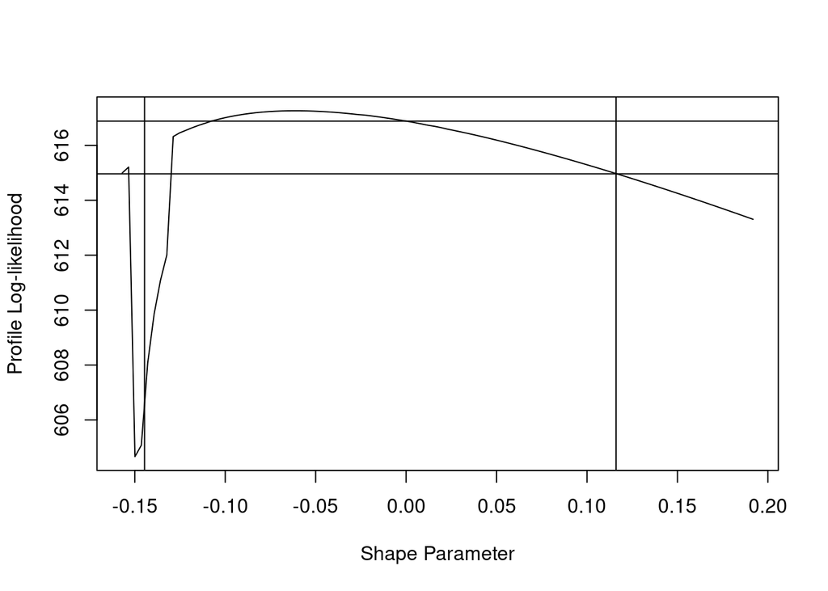

```
##   conf.inf   conf.sup
## -0.1446114  0.1160766
```

```r
sigmasim
```

```
##       scale
## 0.007232329
```

```r
confint(GPsim, parm="scale", level=0.95)
```

```
## If there is some troubles try to put vert.lines = FALSE or change
##  the range...
```

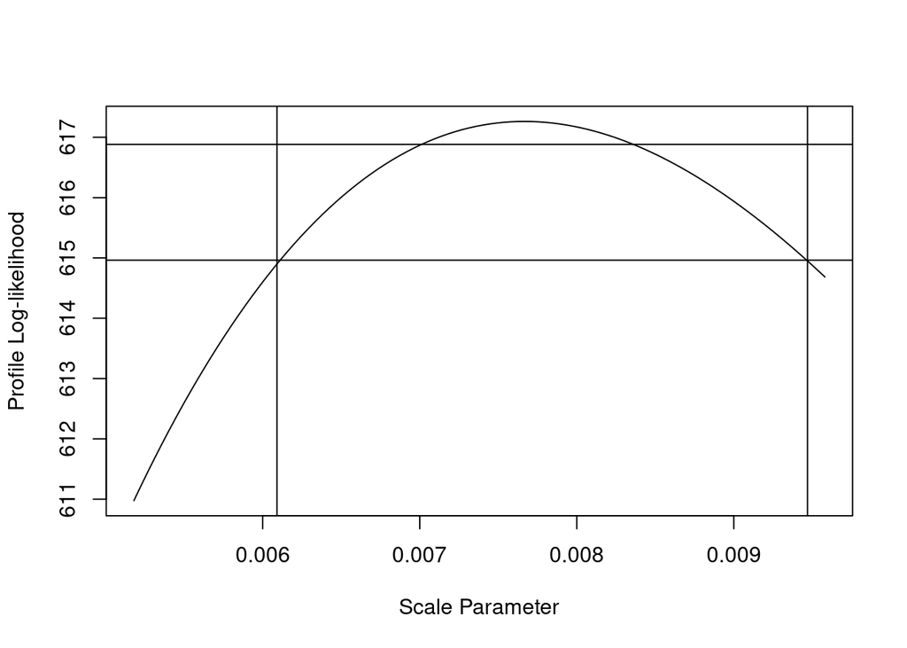

```
##    conf.inf    conf.sup
## 0.006091046 0.009469049
```

¿Qué podemos decir de la distribución en base al $\xi$? ¿Cómo es la distribución de afectaciones?

### Figura ejemplo

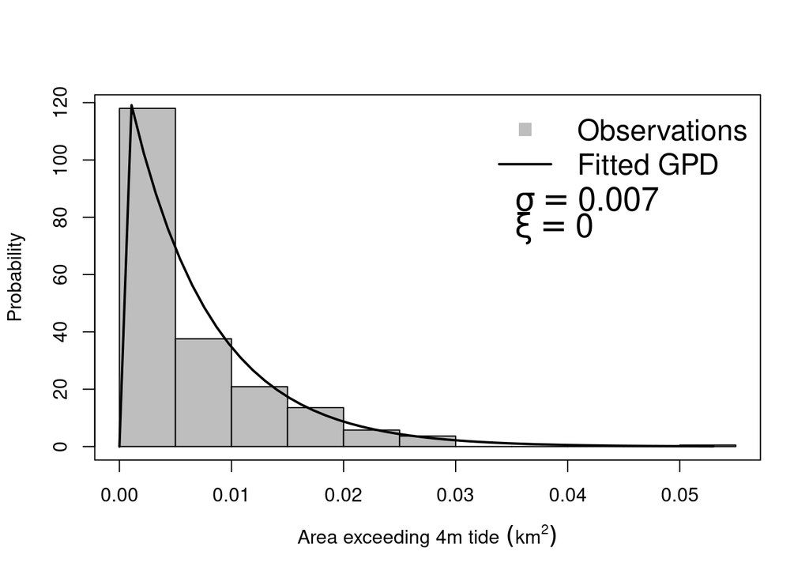

```r
#x11(width = 6, height = 6)
#jpeg(filename = "DensidadExcesossimulada.jpeg",width = 6, height = 6, units = "in", pointsize = 12,quality = 100,bg = "white", res = 200)

hist(AreaExceso[AreaExceso>1e-3],breaks=15, prob=T, xlab=expression("Area exceeding 4m tide" ~(km^2)), main="",ylab="Probability", col="grey")
box()
legend("topright", legend=c("Observations", "Fitted GPD"), pch=c(15,NaN),lty=c(NaN,1),lwd=2,bty="n", cex=1.5,col=c("grey","black"))
x_aux<-seq(0,max(AreaExceso), length=50)
lines(x_aux,dgpd(x_aux, 0, sigmasim,ksim),lwd=2)
#legend(25000, 0.0001, legend=c(expression(paste(sigma, " = ", 5579)),expression(paste(xi, " = ", 0.11))),bty="n", cex=1.5)
legend(0.03, 100, legend=bquote(sigma == .(round(sigmasim,3))), bty="n", cex=1.7)
legend(0.03, 90, legend=bquote(xi == .(round(ksim,3))), bty="n", cex=1.7)
```

Y podemos hacer una figura donde se muestren dos casos particulares y como son los excesos. Para eso generamos una función accesoria para dibujar las lineas (vlines) y luego hacemos el plot.

```r
## FIGURE SIMULATION
vlines <- function(x, y, y.orig, lwd=1, col="black"){
        for (i in seq(along=x))lines(x[c(i,i)], c(y.orig, y[i]), lwd=lwd, col=col)
        }
```

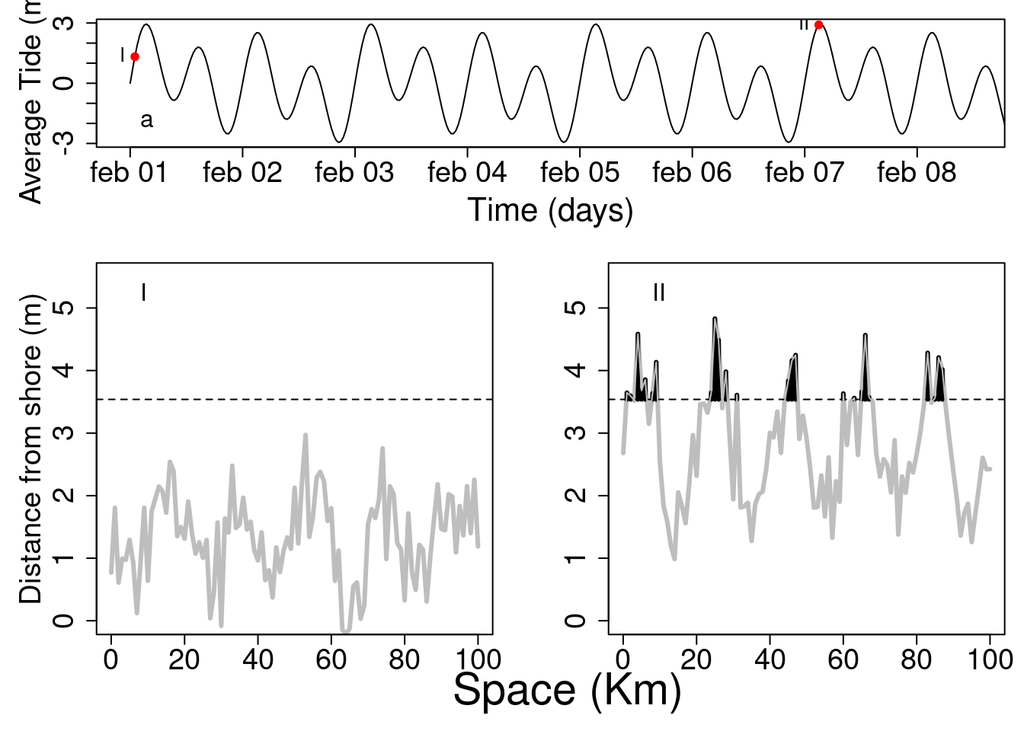

```r
#jpeg(filename = "Siimulation_BeachTideHeight.jpeg",width = 12, height = 10, units = "in", pointsize = 12,quality = 100,bg = "white", res = 100)

layout(matrix(c(1, 1,
                2, 3,
                2, 3), nrow=3, byrow=TRUE))
#layout.show(n=3)
par(mar=c(5,5,1,1))
plot(x,Averagetide, type="l", xlim=c(x[1], x[360]), axes=FALSE, xlab="Time (days)", ylab="", cex.lab=2, cex.axis=1.5)
axis.POSIXct(1, at=seq(x[1], x[360], by="day"), format="%b %d", cex.axis=1.8)
box()
axis(2, cex.axis=1.8)
points(x[3],Averagetide[3], pch=19, col="red")
points(x[295],Averagetide[295], pch=19, col="red")
text(x[3],Averagetide[3],"I",pos=2, cex=1.2)
text(x[295],Averagetide[295],"II",pos=2, cex=1.2)
legend("bottomleft", legend="a", bty="n", cex=1.5)

mtext("Average Tide (m)",2, cex=1.2,line=2.7, at=-0.5)

plot(xSpace,TideMAt[,3], lwd=3, type="l", ylim=c(0,5.5), xlab="", ylab="", cex.lab=1.8, cex.axis=1.8, col="gray")
abline(h=u, lty=2)
legend("topleft", legend="I", bty="n", cex=1.5)

mtext( "Distance from shore (m)",2, line=2.7, cex=1.2)

plot(xSpace,TideMAt[,295], lwd=3, type="l", ylim=c(0,5.5),xlab="",ylab="", cex.lab=1.8, cex.axis=1.8, col="gray")
abline(h=u, lty=2)
auxTideMat<-TideMAt[,295]
auxTideMat[auxTideMat<u]<-NaN

vlines(xSpace, y=auxTideMat, y.orig=u, lwd=3, col="black")
lines(xSpace,TideMAt[,295], lwd=1, type="l", col="gray")

mtext( "Space (Km)",1, line=2.8, at=-15,cex=1.8)
legend("topleft", legend="II", bty="n", cex=1.5)
```